# Lecture 08

2026-04-21

## Activity 1 (Always Anonymous)

### QR Code (it’s getting better)

This is anonymous & optional, but helpful to Stats 20,

[figure not shown]

or here is a [direct link](https://www.menti.com/bl3ovtgc28d7)

# Base R Graphics

## Quick Survey

- While `plot()` can do many things, you should have some knowledge of other functions if you were limited to using base R and no access additional libraries.
- barplot
- mosaicplot
- boxplot
- heatmap
- hist
- pairs
- persp
- contour

# Barplot

## Rectangles are the clearest

```r
help(barplot)
```

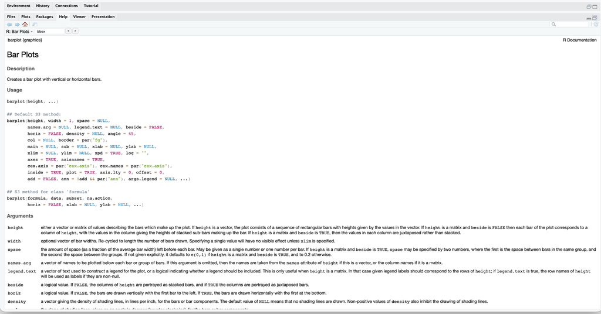

barplot_help

## Barplot is “not smart”

- barplot() will not do math for you, so your data must be in totals (or tabled)
- if it is a vector (one-way table), each value will be a bar
- if it is a matrix (two-way table), each column will be bar

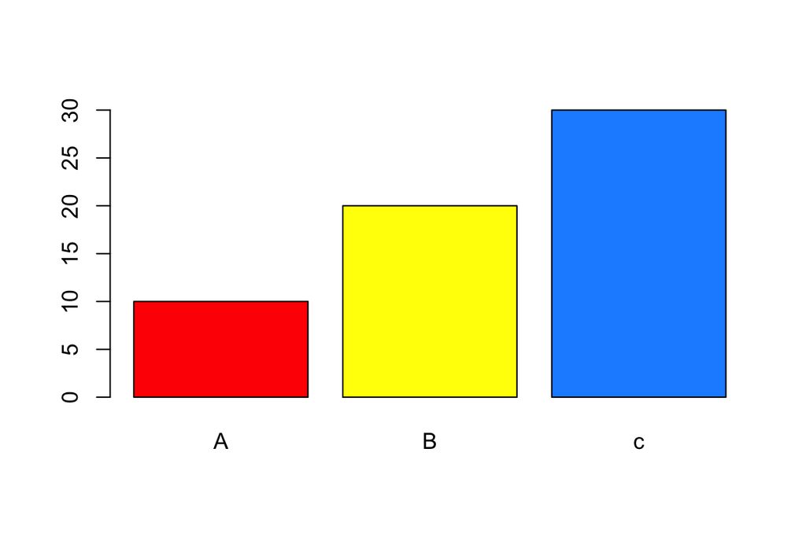

```r
# Each value gets a bar and a color
my_vector <- c(A = 10, B = 20, c = 30)
barplot(my_vector, col = c("red", "yellow", "dodgerblue"))
```

## Matrix example

- The assumption is that the numerical values are some type of total or count value
- Matrices need to be convert to a two-way table to be plotted here

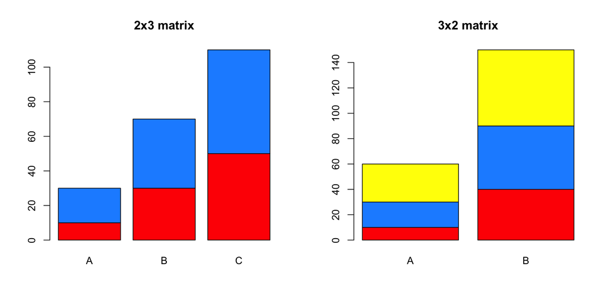

```r
op <- par() # store the defaults, turn your warnings off
par(mfrow = c(1,2)) # change the plot window appearance
matrix(seq(10, 60, by= 10), nrow = 2) |> as.table() |> barplot(col = c("red", "dodgerblue"), main = "2x3 matrix")
matrix(seq(10, 60, by= 10), nrow = 3) |> as.table() |> barplot(col = c("red", "dodgerblue", "yellow"), main = "3x2 matrix")
```

```r
par(op) # restore the original
```

## Aside: table()

- The table() function is ancient but easy and useful. Especially when trying to build data for plots
- from the documentation, simplified

```
table(...,
      exclude = if (useNA == "no") c(NA, NaN),
      useNA = c("no", "ifany", "always"),
      dnn = list.names(...), deparse.level = 1)

...        one or more objects which can be interpreted as factors (including numbers or character strings), or a list (such as a data frame) whose components can be so interpreted.
exclude  levels to remove for all factors in .... If it does not contain NA and useNA is not specified, it implies useNA = "ifany".
```

- it needs to be demo’ed, then you are quite clever and can build on the basics
- I would recommend always setting `useNA = "always"` until you know there are no NA in your data or have dealt with them.

## table() introduction

- Let’s use, “pokemon.RData”, which contained one data frame called `pokemon_df`
- A mix of numeric and non-numeric data, how to work with the non-numeric?
- Look for variables with only a few unique values to get a distribution of counts which could be converted to proportions

```r
load("pokemon.RData")
ls()
```

```
[1] "my_vector"  "op"         "pokemon_df"
```

```r
names(pokemon_df)
```

```
 [1] "id"              "pokemon"         "species_id"      "height"
 [5] "weight"          "base_experience" "type_1"          "type_2"
 [9] "hp"              "attack"          "defense"         "special_attack"
[13] "special_defense" "speed"           "color_1"         "color_2"
[17] "color_f"         "egg_group_1"     "egg_group_2"     "url_icon"
[21] "generation_id"   "url_image"
```

```r
unique(pokemon_df$egg_group_1) # unique answers "how many unique values" aslo pokemon_df[["egg_group_1"]]
```

```
 [1] "monster"       "bug"           "flying"        "ground"
 [5] "no-eggs"       "fairy"         "plant"         "water1"
 [9] "humanshape"    "water3"        "mineral"       "indeterminate"
[13] "water2"        "ditto"         "dragon"
```

```r
unique(pokemon_df$generation_id) # this is numeric, but limited values
```

```
[1]  1  2  3  4  5  6  7 NA
```

## table useNA = “always”

- Because data is almost never perfect

```r
table(pokemon_df$generation_id)
```

```
  1   2   3   4   5   6   7
151 100 135 107 156  72  81
```

- BUT

```r
table(pokemon_df$generation_id, useNA= "always")
```

```
   1    2    3    4    5    6    7 <NA>
 151  100  135  107  156   72   81  147
```

- You might have the wrong impression if you don’t account for missingness,

```r
(table(pokemon_df$generation_id)  |> prop.table()) |> round(digits = 2)
```

```
   1    2    3    4    5    6    7
0.19 0.12 0.17 0.13 0.19 0.09 0.10
```

```r
(table(pokemon_df$generation_id, useNA= "always") |> prop.table()) |> round(digits = 2)
```

```
   1    2    3    4    5    6    7 <NA>
0.16 0.11 0.14 0.11 0.16 0.08 0.09 0.15
```

# Mosaicplot

## Mosaicplot (for tables)

- These display the relationship between two or more non-numeric variables

```r
mosaicplot(table(pokemon_df$generation_id, pokemon_df$type_1,
               useNA= "always"),
               main = "Pokemon Type by Generation",
               las=1, # labels always horizontal
               col = c("#A8B820", "#F08030", "#6890F0", "#78C850", "#F8D030",
               "#FA8072", "#E0C068", "#EE99AC", "#C03028", "#A040A0",
               "#A8A878", "#B8A038", "#705898", "#98D8D8", "#7038F8",
               "#B8B8D0", "#D89090"))
```

## Mosaicplot result

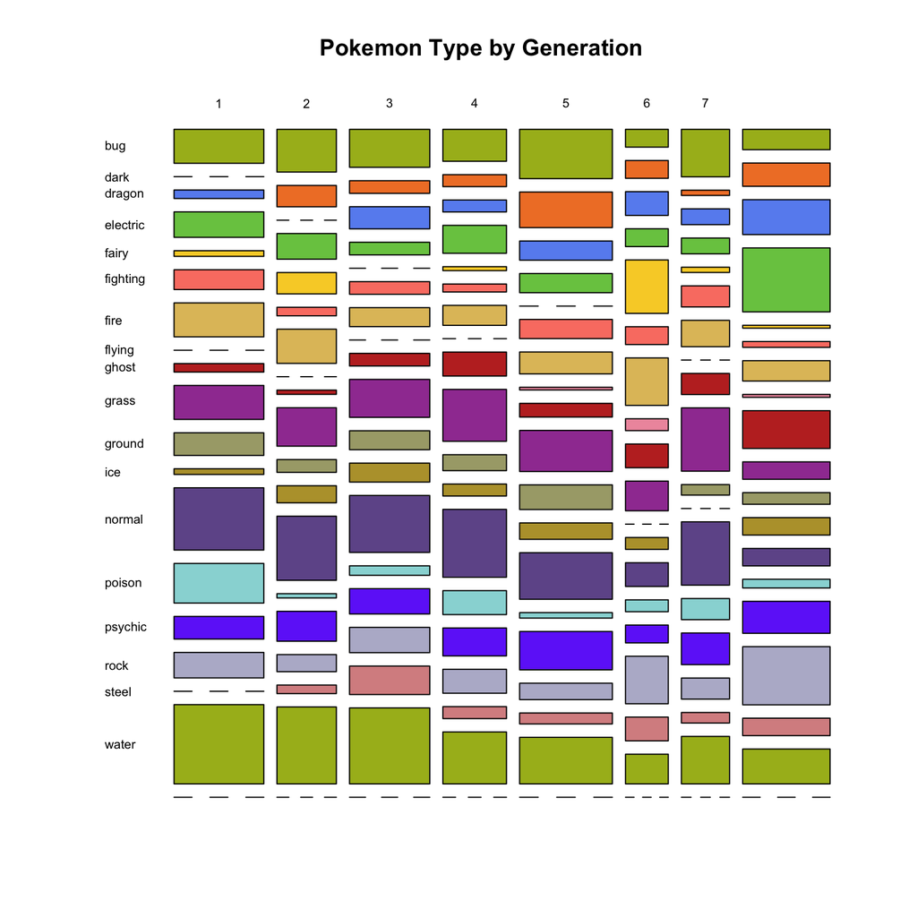

# Boxplot

## Boxplot

- Best application - 2 variables - one numeric, one categorical (grouping)

```
Usage
boxplot(x, ...)

## S3 method for class 'formula'
boxplot(formula, data = NULL, ..., subset, na.action = NULL,
        xlab = mklab(y_var = horizontal),
        ylab = mklab(y_var =!horizontal),
        add = FALSE, ann = !add, horizontal = FALSE,
        drop = FALSE, sep = ".", lex.order = FALSE)

## Default S3 method:
boxplot(x, ..., range = 1.5, width = NULL, varwidth = FALSE,
        notch = FALSE, outline = TRUE, names, plot = TRUE,
        border = par("fg"), col = "lightgray", log = "",
        pars = list(boxwex = 0.8, staplewex = 0.5, outwex = 0.5),
         ann = !add, horizontal = FALSE, add = FALSE, at = NULL)
```

## Boxplot (cont’d)

- Recommend the formula method because it is cleaner looking
- But the older style works just fine, whatever is easiest for you

```r
boxplot(defense ~ type_1,
        data = pokemon_df,
        main = "Boxplot of defense by first type",
        xlab = "first type",
        ylab = "points",
        col = c("#A8B820", "#F08030", "#6890F0", "#78C850", "#F8D030", "#FA8072", "#E0C068", "#EE99AC", "#C03028", "#A040A0",
        "#A8A878", "#B8A038", "#705898", "#98D8D8", "#7038F8", "#B8B8D0", "#D89090")
        )
```

- note the colors are extracted from the data, and are in “hex” (see [Google Color Picker](https://share.google/Xb93LQWAlCYzKd0yv))
- note the problem with the x-axis we have so many categories (next slide)

## Result

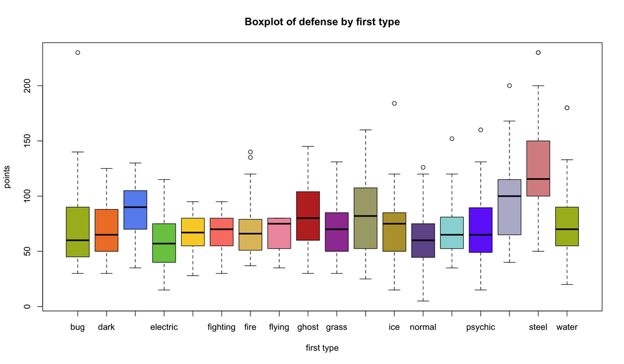

## Aside - cex.axis=

- Shrink the x-axis labels using graphical options from plot()

```r
boxplot(defense ~ type_1, data = pokemon_df,
        main = "Boxplot of defense by first type", xlab = "first type", ylab = "points",
        col = c("#A8B820", "#F08030", "#6890F0", "#78C850", "#F8D030",
                "#FA8072", "#E0C068", "#EE99AC", "#C03028", "#A040A0",
                "#A8A878", "#B8A038", "#705898", "#98D8D8", "#7038F8", "#B8B8D0", "#D89090"),
        cex.axis = 0.85
        )
```

## Result - cex.axis=

- Shrink the x-axis labels using graphical options from plot()

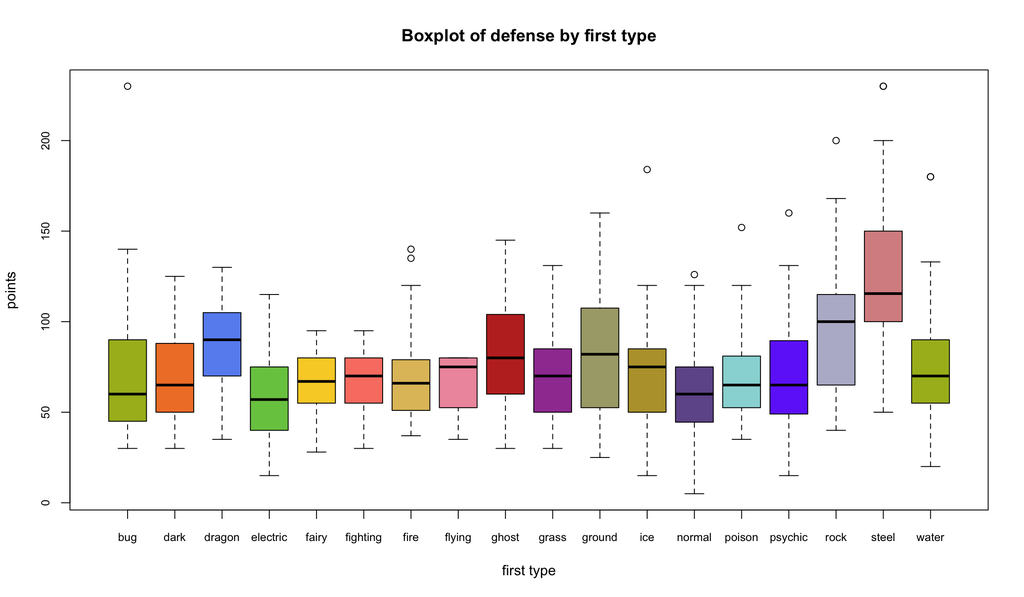

# Heatmap

## Heatmap

- We can draw better and more flexible heatmaps using other packages but base R has one and if you haven’t seen one before, here is your introduction.

```r
x  <- as.matrix(pokemon_df[c(6, 150, 130, 131, 132, 133, 1, 143, 4, 94, 59, 38, 65, 25, 26), c(4:6, 9:14)])
row.names(x) <- pokemon_df$pokemon[c(6, 150, 130, 131, 132, 133, 1, 143, 4, 94, 59, 38, 65, 25, 26)]
heatmap(x, Colv = NA, Rowv = NA, col = hcl.colors(256), scale = "column",
        xlab = "", ylab =  "",
        main = "Heatmap of some Pokemon and their Abilities", cexCol = 0.7)
```

## Heatmap result

[figure not shown]

## Takeaway for the Heatmap

- A heat map is a just tool like the others tools
- It is a scaled matrix of numerical values represented by colors
- They represent Z-scores (standard deviations from the mean of the column)
- A “Hot” color (here, Yellow): This value is high relative to other values.
- A “Cold” color (here deep Purple): This value is low relative to the other.

# Histogram

## hist() for histograms

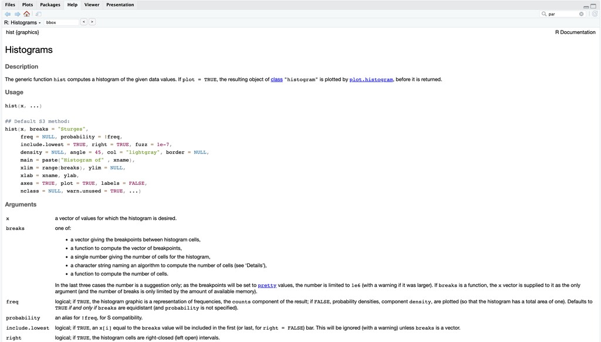

help(hist)

## basic example

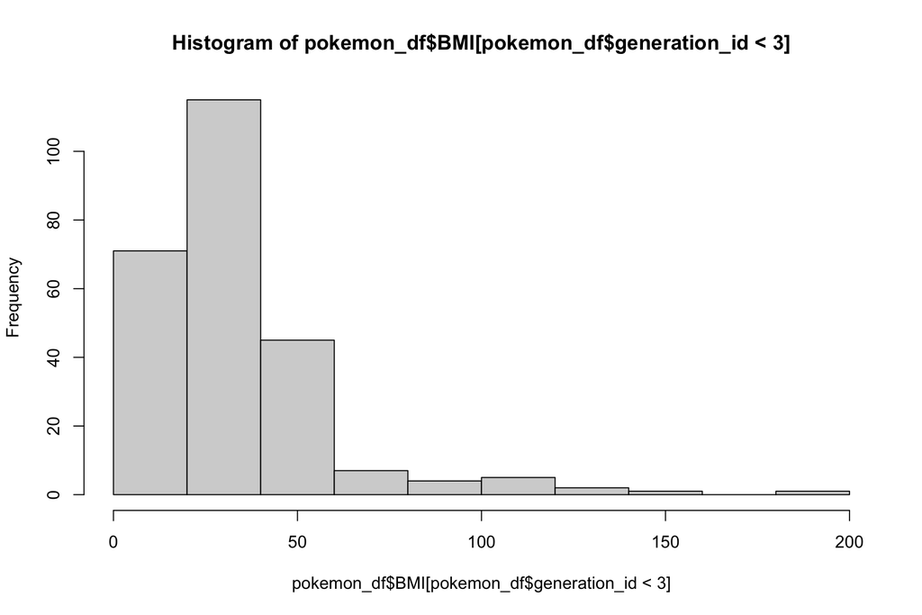

```r
pokemon_df$BMI <- pokemon_df$weight / (pokemon_df$height)^2
hist(pokemon_df$BMI[pokemon_df$generation_id < 3])
```

## common options

- add titles and labels, change color, change to density

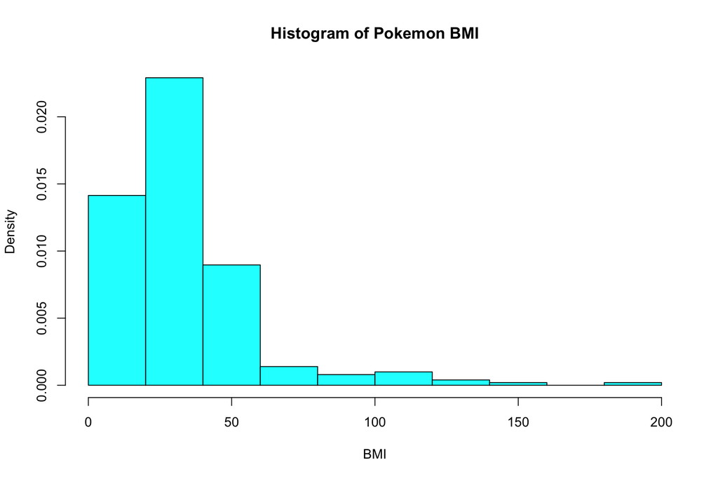

```r
hist(pokemon_df$BMI[pokemon_df$generation_id < 3], prob = TRUE, col = "cyan",
     xlab = "BMI", main = "Histogram of Pokemon BMI")
```

## additional options

- adjust the number of breaks (cells), adjust the height of the y-axis, add lines and legend

```r
hist(pokemon_df$BMI[pokemon_df$generation_id < 3], prob = TRUE, col = "cyan",
     xlab = "BMI", main = "Histogram of Pokemon BMI", breaks = 20, ylim = c(0, 0.03))
# Add density curve
density_curve <- density(pokemon_df$BMI[pokemon_df$generation_id < 3],
                       na.rm = TRUE) # Remove NA values if any
lines(density_curve, col = "red", lwd = 2) # Add density to plot

# Calculate median BMI for each generation
median_bmi01 <- median(pokemon_df$BMI[pokemon_df$generation_id == 1],
     na.rm = TRUE)
median_bmi02 <- median(pokemon_df$BMI[pokemon_df$generation_id == 2],
     na.rm = TRUE)

# Add vertical line for median BMIs for gen1 and gen2
abline(v = median_bmi01, col = "blue", lwd = 2, lty = 2)
# Add vertical line with blue color, width 2, and dashed line type
abline(v = median_bmi02, col = "magenta", lwd = 2, lty = 2)
# Add vertical line with magenta color, width 2, and dashed line type

# Add legend with location, text, specified colors and line types
legend("topright",
       legend = c("Density Curve", "Median BMI Gen 1", "Median BMI Gen 2"),
       col = c("red", "blue", "magenta"), lwd = 2, lty = c(1, 2, 2))
```

## result

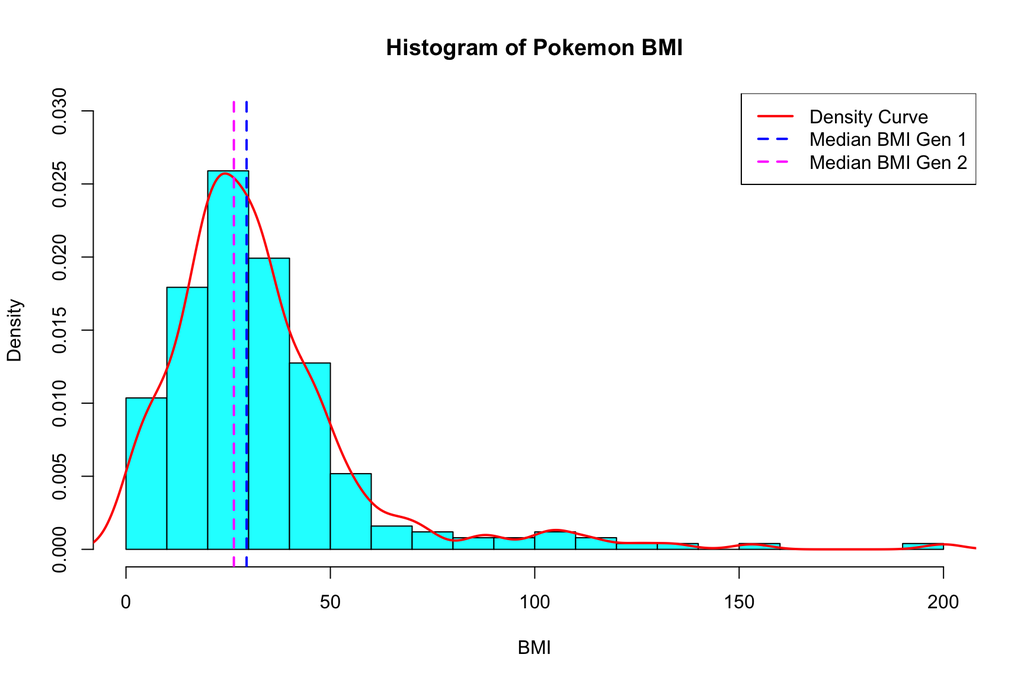

# And others

## image, persp, contour

- image() displays data as a image, contour() as lines of equal height, and persp() as a 3D surface. All using the same data in a panel display

```r
# Save current graphical settings
op <- par()

# Layout: 1 row, 3 columns
par(mfrow = c(1, 3), mar = c(4, 4, 3, 2), oma = c(0, 0, 2, 0))

# Image (heatmap-style)
image(
  volcano,
  col = terrain.colors(20),
  main = "image(volcano)",
  xlab = "X",
  ylab = "Y"
)

# Contour
contour(
  volcano,
  col = "darkgreen",
  lwd = 1.2,
  main = "contour(volcano)",
  xlab = "X",
  ylab = "Y"
)

# Perspective (3D)
persp(
  volcano,
  theta = 40,
  phi = 20,
  expand = 0.6,
  col = "tan",
  shade = 0.5,
  border = "gray",
  main = "persp(volcano)"
)

# Overall title
mtext("Three Views of the Same Data (volcano matrix)", outer = TRUE)

# Restore settings
par(op)
```

## Result

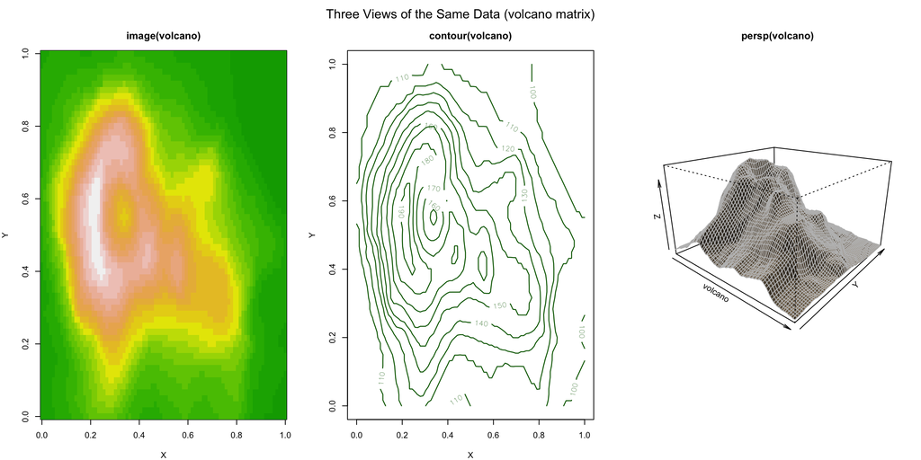

## Recap: Basic Tools for Visualization

- Tables (later): counts, proportions, descriptive statistics.
- Univariate plots: histograms, density plots, boxplots.
- Bivariate plots: scatterplots, grouped bar charts.

## Activity #2 Attendance

### Please Greet Your Neighbor(s)

- Hopefully, you are comfortable greeting your neighbors now.
- Reminder: You need at least one different neighbor each week for your attendance credit (only one photo required)
- Reminder: You cannot receive credit if it’s only you in the photo, please refrain from photoshopping/editing photos
- [Things are looking better all the time](https://sph.umich.edu/news/2025posts/college-student-mental-health-third-consecutive-year-improvement.html)
- Meet a new classmate, take a photograph.

# Tidyverse - ggplot2

## What is it?

The Tidyverse is a collection of R packages designed for:

> cleaning, transforming, visualizing, and analyzing data in a consistent way

Core packages include:

- dplyr for data manipulation
- ggplot2 for visualization
- tidyr for reshaping data
- readr for importing data

It integrates fully with base R, it a set of tools

## R for Data Science (book)

- Associated with Tidyverse (same author)
- Visualization - two purposes to communicate or to explore
- Communicate - explain or report a result
  - Audience is other people
  - Clean, polished, consistent color & labels
- Explore - discover relationships in data
  - Audience is mostly you and possibly collaborators
  - Fast, flexible, rough, many plots,

### Supporting texts

- [R for Data Science 2nd ed](https://r4ds.hadley.nz/) (free)
- [ggplot2 edition 3](https://ggplot2-book.org/) (free)

## Suggestions for R for Data Science

- [Chapter 1](https://r4ds.hadley.nz/data-visualize.html) is on building the Data Visualization given a “story or need to communicate”
- [Chapter 10](https://r4ds.hadley.nz/EDA.html) on EDA, no story, discovery

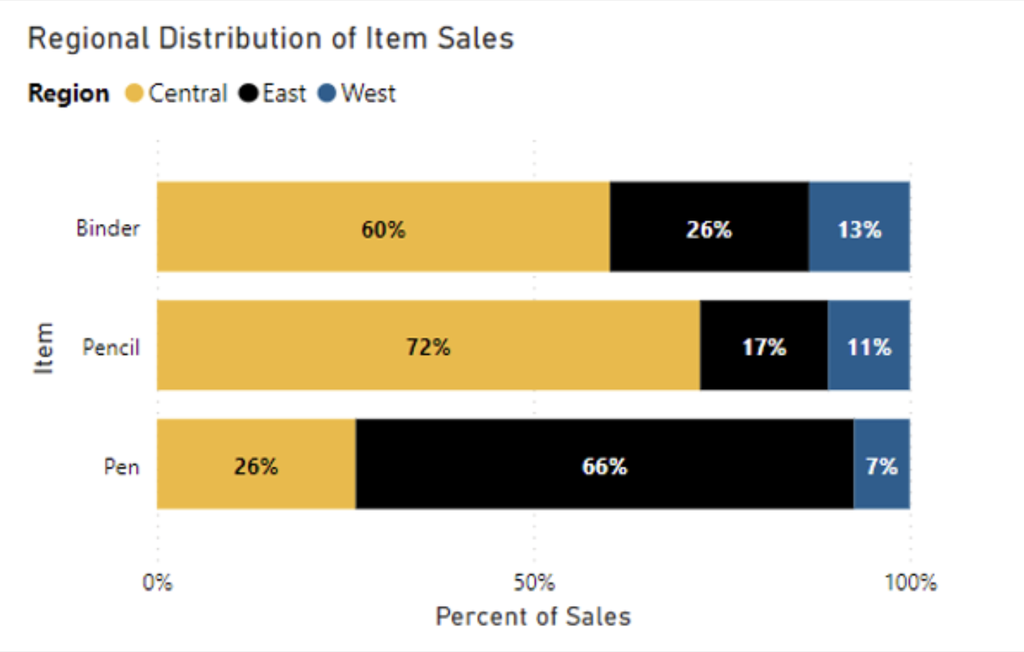

# ggplot2

[figure not shown]

ggplot is part of the Tidyverse in R

- `gg` means “Grammar of Graphics”
- The **Grammar of Graphics** was written by Leland Wilkinson in 1999.
- Wilkinson detailed a comprehensive framework to describe and build a wide range of statistical graphics by breaking down the elements of graphics into a unified system.

## Grammar of Graphics

[figure not shown]

Source: https://www.stat20.org/

## Data

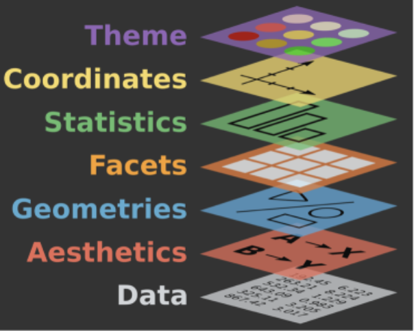

- In GG, data is the foundation of any visualization
- All graphical representation decisions rest on top of it
- All the decisions are data-driven
- Result: meaningful and accurate visual representation of data
- AND a wide variety of graphics

## Aesthetics (Aesthetic Mappings)

- These are the rules
- They map (connect) data variables to the visual properties of the graphical elements
- Most frequently - x, y, color, size, and shape
- The connection of data to graphical elements allow us to see/interpret patterns, trends, and anomalies within the data

## Geometries include

- Points, typically used for individual values
- Lines, connect points in some defined order (e.g., time, location)
- Bars, typically used for categories (e.g., pizza types)
- Polygons, use to represent areas (maps)
- Paths, fatter lines, used to represent flows (Sankey)

## from the ggplot2 cheatsheet

[figure not shown]

## Facets and Layers

- Conditioning the data, so working with groups
- Subsets are facets
- Layers combine multiple types of visualizations into a single graphic

## Statistics

- Data can be summarized or modified prior to visualization
  - Aggregation (like sums or means),
  - smoothing
- Can clarify the underlying structure or relationships in data.

## Coordinates and scales

- Scaling (linear, logarithmic, etc.)
- Coordinate systems (Cartesian, polar, etc.).
- They influence the position of data points (and the interpretation).

## Themes

- Control the overall “look” (styling) of the graphic
- fonts, colors
- labeling, legends, captioning
- layout etc.

## Give me 5 minutes

- You will need these package installed and loaded for the next few slides, but we will go through the code together, so don’t worry if you don’t have them yet.
- You can also try today’s activity, it’s loaded these already.

```r
library(readr)
library(tidyverse)
library(knitr)
library(ggthemes)
library(palmerpenguins)
```

## Five minute ggplot

### The Data

If there is only one package you need in R, it’s ggplot2. It’s simple and logical and flows with data beautifully. We can use penguins

```r
str(penguins)
```

```
tibble [344 × 8] (S3: tbl_df/tbl/data.frame)
 $ species          : Factor w/ 3 levels "Adelie","Chinstrap",..: 1 1 1 1 1 1 1 1 1 1 ...
 $ island           : Factor w/ 3 levels "Biscoe","Dream",..: 3 3 3 3 3 3 3 3 3 3 ...
 $ bill_length_mm   : num [1:344] 39.1 39.5 40.3 NA 36.7 39.3 38.9 39.2 34.1 42 ...
 $ bill_depth_mm    : num [1:344] 18.7 17.4 18 NA 19.3 20.6 17.8 19.6 18.1 20.2 ...
 $ flipper_length_mm: int [1:344] 181 186 195 NA 193 190 181 195 193 190 ...
 $ body_mass_g      : int [1:344] 3750 3800 3250 NA 3450 3650 3625 4675 3475 4250 ...
 $ sex              : Factor w/ 2 levels "female","male": 2 1 1 NA 1 2 1 2 NA NA ...
 $ year             : int [1:344] 2007 2007 2007 2007 2007 2007 2007 2007 2007 2007 ...
```

- a tibble (tbl) is a modern version of a data frame, it is part of the tidyverse, and it has some nice features that make it easier to work with than a traditional data frame.
- It is also more strict about how you can use it, which can be helpful for avoiding mistakes. You can convert a tibble to a data frame with `as.data.frame()` if you need to.

## Tibble example

```r
penguins
```

```
# A tibble: 344 × 8
   species island    bill_length_mm bill_depth_mm flipper_length_mm body_mass_g
   <fct>   <fct>              <dbl>         <dbl>             <int>       <int>
 1 Adelie  Torgersen           39.1          18.7               181        3750
 2 Adelie  Torgersen           39.5          17.4               186        3800
 3 Adelie  Torgersen           40.3          18                 195        3250
 4 Adelie  Torgersen           NA            NA                  NA          NA
 5 Adelie  Torgersen           36.7          19.3               193        3450
 6 Adelie  Torgersen           39.3          20.6               190        3650
 7 Adelie  Torgersen           38.9          17.8               181        3625
 8 Adelie  Torgersen           39.2          19.6               195        4675
 9 Adelie  Torgersen           34.1          18.1               193        3475
10 Adelie  Torgersen           42            20.2               190        4250
# ℹ 334 more rows
# ℹ 2 more variables: sex <fct>, year <int>
```

## Specifying the data and aes()

AT MINIMUM ggplot needs to know what data you plan to use and it needs to have an aesthetic (aes) specified. We will choose two numeric variables.

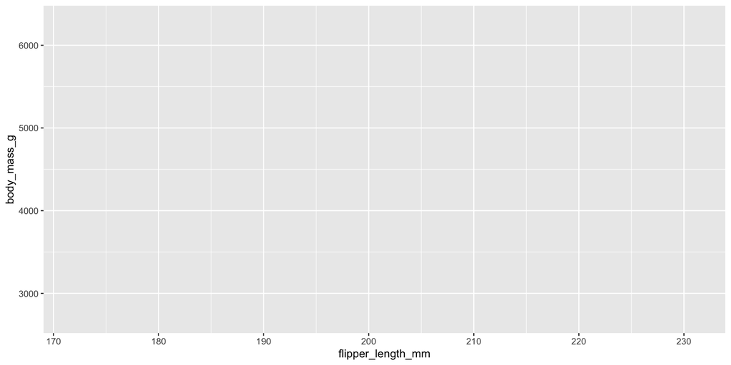

```r
ggplot(data = penguins,
       aes(x = flipper_length_mm,
           y = body_mass_g))
```

No error, but no graphic. All we have done is specified the data and given ggplot a sense of how the graphic should appear (x, y) as it relates to the features.

## Adding a geom layer

- The “+” in ggplot separates “layers” of a graphic.
- Think of ggplot as like making a cake, you lay down the foundation and then you start decorating. The geom_ will tell ggplot how the aesthetic values should be plotted.

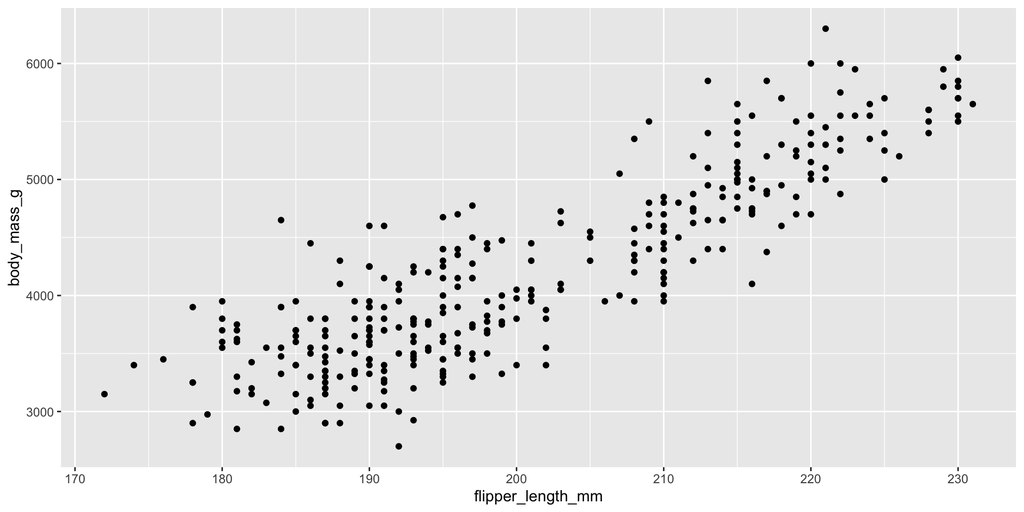

```r
ggplot(data = penguins,
       aes(x = flipper_length_mm,
           y = body_mass_g)) +
  geom_point()
```

That is about five minutes. The rest of ggplot is about beautifying your graphic through additional options. Mapping the data to the aesthetic then is the most critical skill here.

## ggplot in detail

Ok let’s slow down, identify the data types within the dataset

```r
str(penguins)
```

```
tibble [344 × 8] (S3: tbl_df/tbl/data.frame)
 $ species          : Factor w/ 3 levels "Adelie","Chinstrap",..: 1 1 1 1 1 1 1 1 1 1 ...
 $ island           : Factor w/ 3 levels "Biscoe","Dream",..: 3 3 3 3 3 3 3 3 3 3 ...
 $ bill_length_mm   : num [1:344] 39.1 39.5 40.3 NA 36.7 39.3 38.9 39.2 34.1 42 ...
 $ bill_depth_mm    : num [1:344] 18.7 17.4 18 NA 19.3 20.6 17.8 19.6 18.1 20.2 ...
 $ flipper_length_mm: int [1:344] 181 186 195 NA 193 190 181 195 193 190 ...
 $ body_mass_g      : int [1:344] 3750 3800 3250 NA 3450 3650 3625 4675 3475 4250 ...
 $ sex              : Factor w/ 2 levels "female","male": 2 1 1 NA 1 2 1 2 NA NA ...
 $ year             : int [1:344] 2007 2007 2007 2007 2007 2007 2007 2007 2007 2007 ...
```

and let’s fix some issues with missing values or we will get lots of warnings

```r
my_penguins <- na.omit(penguins) # dumps all of the NA values, very severe, but we will learn how to deal with missing data later
```

## Non-Numeric Variables

- How do we work with non-numeric information (like gender)? We could group the data by color for example

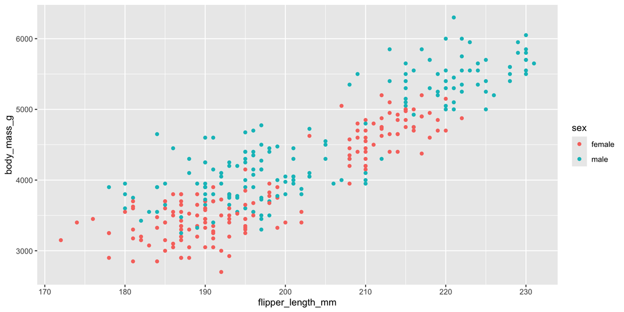

```r
ggplot(data = my_penguins,
       aes(x = flipper_length_mm,
           y = body_mass_g,
           color = sex)) +
  geom_point()
```

## Non-Numeric Variables (cont’d)

- We could group the data by size for example

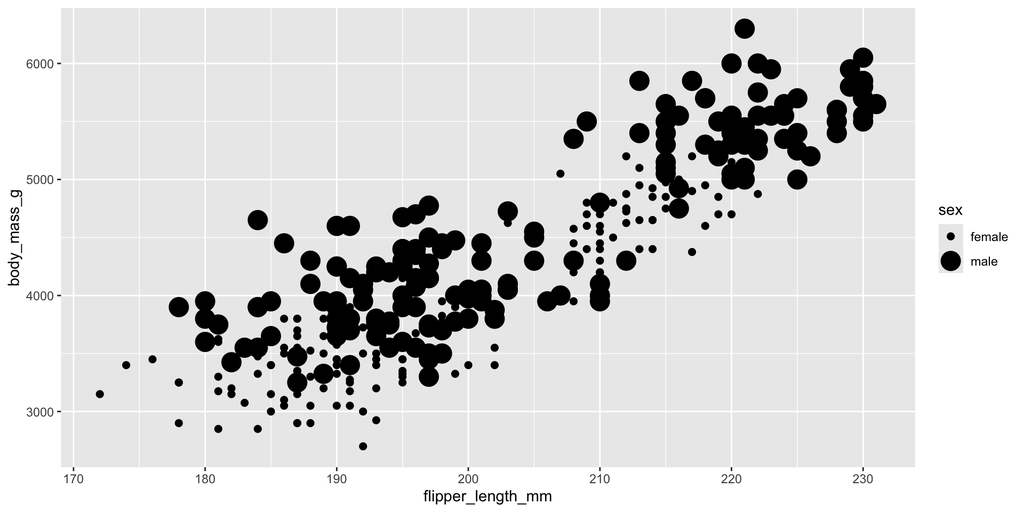

```r
ggplot(data = my_penguins,
       aes(x = flipper_length_mm,
           y = body_mass_g,
           size = sex)) +
  geom_point()
```

## Non-Numeric Variables (and more)

- We could group the data by both

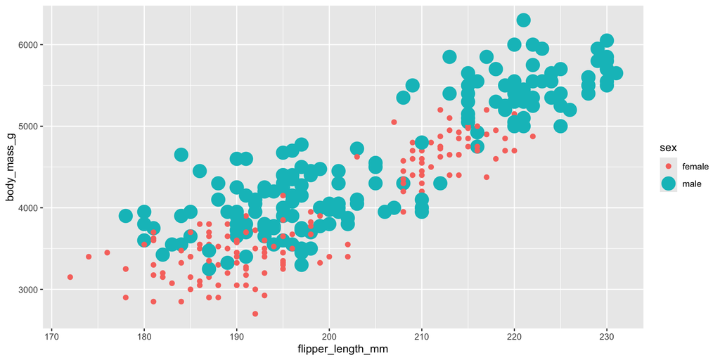

```r
ggplot(data = my_penguins,
       aes(x = flipper_length_mm,
           y = body_mass_g,
           size = sex,
           color = sex)) +
  geom_point()
```

## Modifying the geom()

- a modification inside of the geom is not a mapping, it is an appearance change, so it goes inside the geom() instead of the aes()

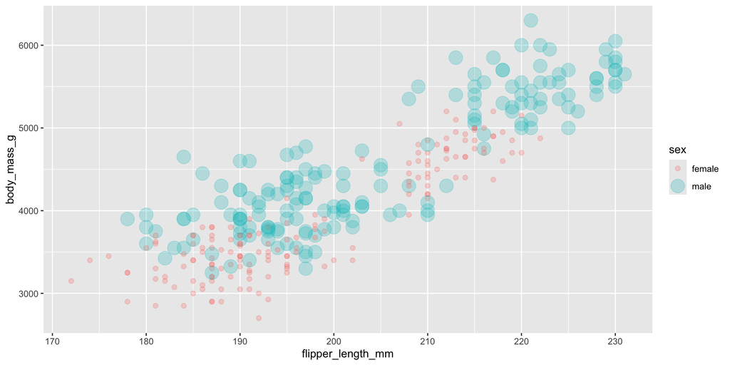

```r
ggplot(data = my_penguins,
       aes(x = flipper_length_mm,
           y = body_mass_g,
           size = sex,
           color = sex)) +
  geom_point(alpha = 0.25)
```

## Modifying the geom() (cont’d)

- But sometimes you see both the aes mapping and the modification in the geom
- This happens when you have very complicated visualizations where you have a “global mapping” (the aes() in the ggplot() call) and then you have a “local mapping” (the aes() in the geom() call) that is different from the global mapping.

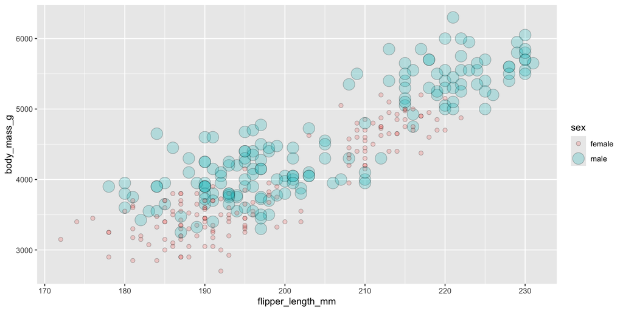

```r
ggplot(data = my_penguins,
       aes(x = flipper_length_mm,
           y = body_mass_g,
           size = sex)) +
  geom_point(aes(fill = sex),
             alpha = 0.25,
             shape = 21,
             color = "black")
```

## Multiple Geoms example

- You might be asking - sometimes you put an aes( ) in the geom, sometimes not? Some would tell you it should only go in the geom() but that works best if you have multiple geoms:

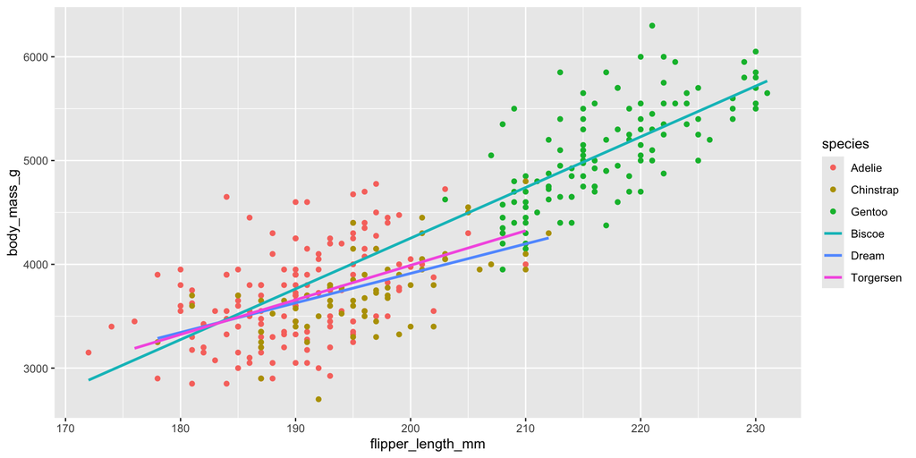

```r
ggplot(data = my_penguins,
       aes(x = flipper_length_mm, y = body_mass_g)) +
  geom_point(aes(color = species)) +
  geom_smooth(aes(color = island),
              method = "lm",
              se = FALSE)
```

- Gets messy though, this suggests an appearance issue, we get into themes (example next slide)

## No legend?

- Sometimes you don’t want a legend, you can turn it off with a theme() modificatio

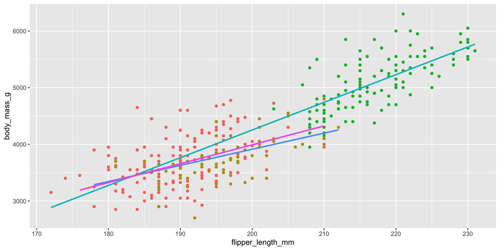

```r
ggplot(data = my_penguins,
       aes(x = flipper_length_mm, y = body_mass_g)) +
  geom_point(aes(color = species)) +
  geom_smooth(aes(color = island),
              method = "lm",
              se = FALSE) +
  theme(legend.position = "none")
```

## Barplot in ggplot

- Go back to something simpler. Plotting categorical variables with different geoms.

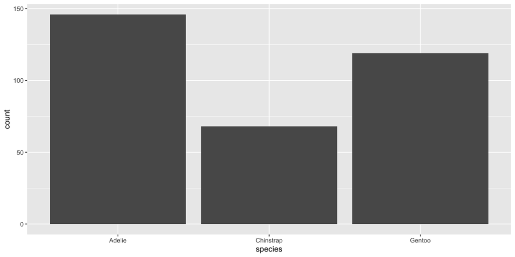

```r
ggplot(data = my_penguins,
       aes(x = species))+
  geom_bar()
```

## Barplot in ggplot - interaction

- Interaction is a handy function, comining sex and species:

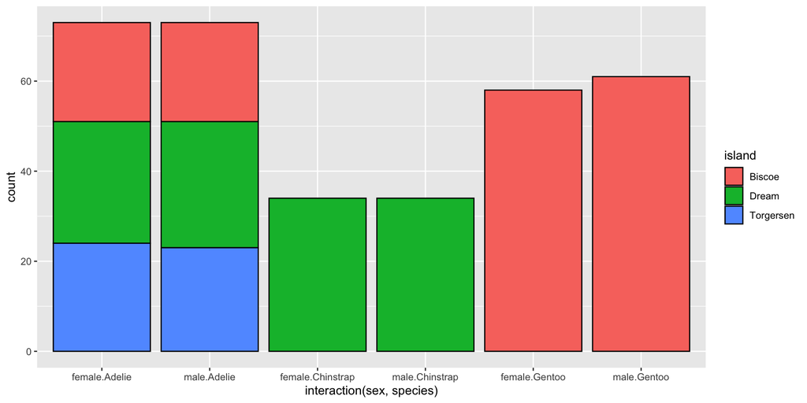

```r
ggplot(data = my_penguins,
       aes(x = interaction(sex, species),
           fill = island)) +
  geom_bar(color = "black")
```

## Barplot in ggplot - interaction

- Notice, we can change the position of the bars, it is accomplished in the geom_bar() with the position argument, “dodge” is a common one for bar charts, it puts the bars next to each other instead of stacked on top of each other

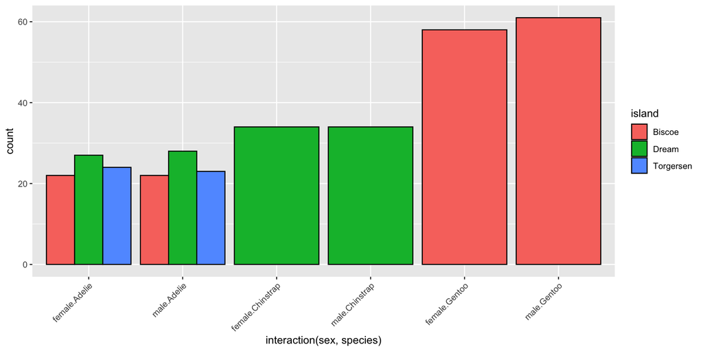

```r
ggplot(data = my_penguins,
       aes(x = interaction(sex, species),
           fill = island)) +
  geom_bar(position = "dodge",
           color = "black") +
  theme(axis.text.x = element_text(angle = 45, hjust = 1))
```

## Faceting - wrap

I do recommend you learn how to “facet” (condition) the plots:

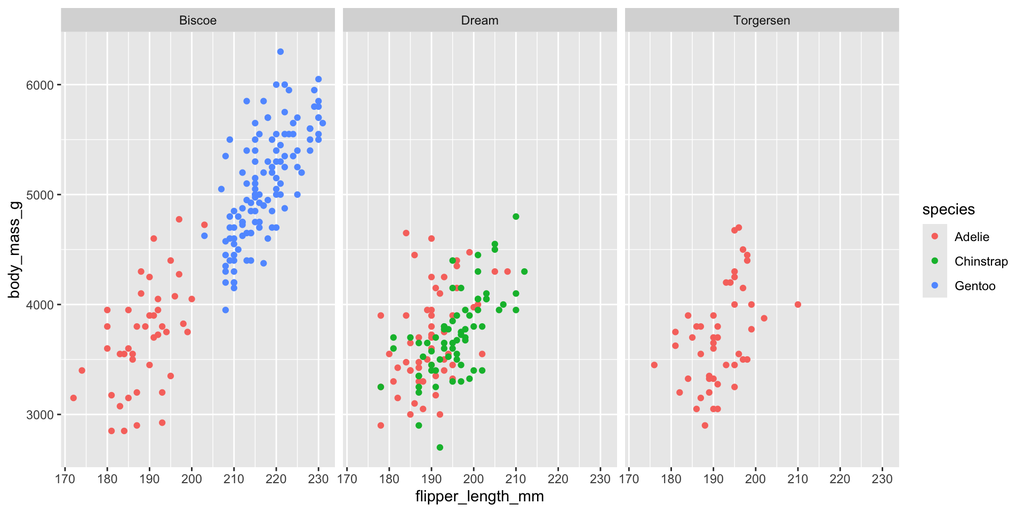

```r
ggplot(data = my_penguins,
       aes(x = flipper_length_mm,
           y = body_mass_g)) +
  geom_point(aes(color = species)) +
  facet_wrap(~ island)
```

read “as a function of island”,

## Faceting - grid

if you wanted island on the rows, move to facet_grid()

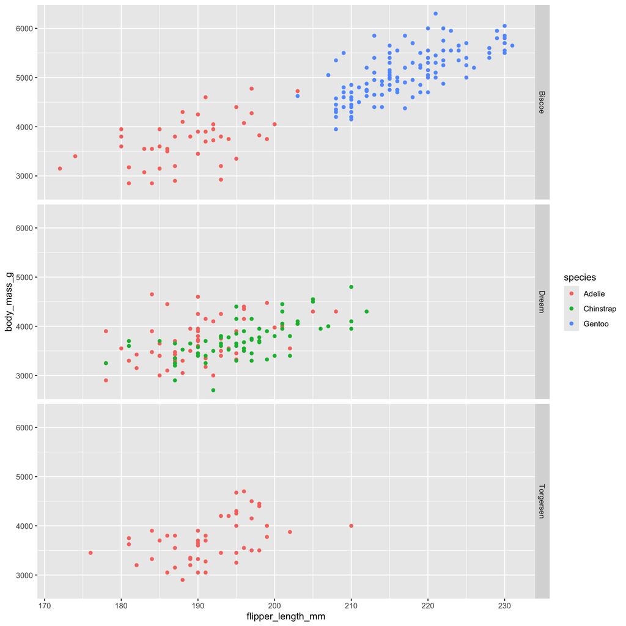

```r
ggplot(data = my_penguins,
       aes(x = flipper_length_mm,
           y = body_mass_g)) +
  geom_point(aes(color = species)) +
  facet_grid(rows = vars(island))
```